# Project 3 - Analysis of Sucide Rates Over the Years

For the purpose of this project, I've chosen to analyze the different rates of suicides across the countries over a time span of thirty years. With increasing awareness, mental health is now given much more importance than earlier times, an important step. Suicides are no longer dismissed and researchers now recognize it as the complex product of varying socioeconomic factors that it really is. Unfortunately there is still a long way to go - while we spend time understanding the the problem, poeple are losing their lives. A recent World Health Organization study reported an estimate that almost 800,000 people commit suicide every year. To put it into perspective the urgency of this problem, that implies a person dies every 40 seconds! With this is mind, I aim to look at suicide data of a hundred countries, to identify the countries at most risk,the breakdown of suicides and mortality rates by different social demographics such as age, sex and race and the change of these rates over time.

For my analysis I've used the pandas package in Python and used a Jupyter notebook to code. I used plotly and matplotlib packages for my visualizations.

I [obtained a data set from Kaggle](https://www.kaggle.com/russellyates88/suicide-rates-overview-1985-to-2016) containing the recorded suicides from 1985 to 2016. It contains data for reported suicide numbers of 101 countries and has individual data for the suicide rates of groups by age, race, gender. It also has the GDP per year and capita values for each particular year. I later used two other data sets - one containing the suicide rates and numbers by race, age group and gender in specifically the United States, and another data set containing the unemployment rates in USA over every month from a time span between 1989 to 2016.

# Pre-Analysis:

The dataset that I am using contains 27,819 rows. The columns in the data set are:

- country
- year
- sex
- age
- suicides_no
- population
- suicides/100kpop
- country-year
- gdp_for_year(dollar sign)
- gdp_per_capita(dollar sign)
- generation

I've renamed some of these columns for better use. While I would have like to use the generation and hdi columns, I noticed that generation had many wrong flags - some age groups aged 25-34 where marked as G.I Generation - and the HDI column did not have much data that I could use. I also removed data for two countries (Dominic and Saint Kitts) as they lacked data and were clashing with my analysis. I had data for 99 countries after I removed them.

Since the data set is full of categorical variables, I repeatedly grouped data from the original data frame, specifying the columns and metrics I needed and then plotted my graphs using them. This helped to keep the data structured and easy on the eyes.

Importing all the necessary packages:

```python
#importing the packages
import pandas as pd
import matplotlib.pyplot as plt
import plotly
from plotly.offline import iplot, init_notebook_mode
init_notebook_mode()
import plotly.graph_objs as go
import plotly.express as px
from plotly.subplots import make_subplots
```

I'm reading in the data set next and converting it to a data frame. After that I'll set the index suitably and rename some of the columns. I'll print out some the first five rows of the data frame to check what the data looks like:

```python
suicide_rates = pd.DataFrame(pd.read_csv("suicide_rates.csv")) # reading the csv file and converting to pandas data frame
suicide_rates.country.unique() #checking to see all teh countries
suicide_rates.set_index('country') # setting index
suicide_rates = suicide_rates[suicide_rates['year'] != 2016].reset_index()
suicide_rates.rename(columns={'suicides/100kpop':'rate_per_hundredkpop', 'gdp_for_year($)':'gdp_year', 'gdp_per_capita($)': 'gdp_capita'}, inplace=True) # renaming columns
suicide_rates.rename(columns = {'gdp_for_year ($)': 'gdp_year'}, inplace=True)
suicide_rates.head(5) #displaying first five rows
#suicide_rates.country.unique())
```

|  | index | country | year | sex | age | suicides_no | population | rate_per_hundredkpop | country-year | HDIforyear | gdp_year | gdp_capita | generation |
| --- | --- | --- | --- | --- | --- | --- | --- | --- | --- | --- | --- | --- | --- |
| 0 | 0 | Albania | 1987 | male | 15-24years | 21 | 312900 | 6.71 | Albania1987 | NaN | 2156624900 | 796 | GenerationX |
| 1 | 1 | Albania | 1987 | male | 35-54years | 16 | 308000 | 5.19 | Albania1987 | NaN | 2156624900 | 796 | Silent |
| 2 | 2 | Albania | 1987 | female | 15-24years | 14 | 289700 | 4.83 | Albania1987 | NaN | 2156624900 | 796 | GenerationX |
| 3 | 3 | Albania | 1987 | male | 75+years | 1 | 21800 | 4.59 | Albania1987 | NaN | 2156624900 | 796 | G.I.Generation |
| 4 | 4 | Albania | 1987 | male | 25-34years | 9 | 274300 | 3.28 | Albania1987 | NaN | 2156624900 | 796 | Boomers |

Looking at the last five rows:

```python
suicide_rates.tail(5) #displaying last five rows
```

|  | index | country | year | sex | age | suicides_no | population | rate_per_hundredkpop | country-year | HDIforyear | gdp_year | gdp_capita | generation |
| --- | --- | --- | --- | --- | --- | --- | --- | --- | --- | --- | --- | --- | --- |
| 27607 | 27767 | Uzbekistan | 2014 | female | 35-54years | 107 | 3620833 | 2.96 | Uzbekistan2014 | 0.675 | 63067077179 | 2309 | GenerationX |
| 27608 | 27768 | Uzbekistan | 2014 | female | 75+years | 9 | 348465 | 2.58 | Uzbekistan2014 | 0.675 | 63067077179 | 2309 | Silent |
| 27609 | 27769 | Uzbekistan | 2014 | male | 5-14years | 60 | 2762158 | 2.17 | Uzbekistan2014 | 0.675 | 63067077179 | 2309 | GenerationZ |
| 27610 | 27770 | Uzbekistan | 2014 | female | 5-14years | 44 | 2631600 | 1.67 | Uzbekistan2014 | 0.675 | 63067077179 | 2309 | GenerationZ |
| 27611 | 27771 | Uzbekistan | 2014 | female | 55-74years | 21 | 1438935 | 1.46 | Uzbekistan2014 | 0.675 | 63067077179 | 2309 | Boomers |

In order to avoid redundancy and keep my notebook clean, I've written functions to automate tasks and added them all in this block:

```python
#Writing a function that will take the year and give a graph of the five countries that faced the most number of suicides for that year
def top_five_countries(year, rownum, columnum, year_str):
    df = pd.DataFrame(suicide_rates[suicide_rates['year'] == year].groupby(['year', 'country']).suicides_no.sum()).reset_index() #filtering out data frame according to need
    df = df.sort_values(by = 'suicides_no' , ascending = False).head(5) #sorting data frame by descending order
    fig.add_trace(go.Bar( #adding the trace for the bar plot
        x = df['country'],
        y = df['suicides_no'],
        name = year_str
    ),row = rownum, col = columnum)
#function that displays the plot for the countries with the top 5 morality rates for a specific year
def top_mortality_rate_for_year(year, rownum, columnum, year_str):
    df = pd.DataFrame(suicide_rates[suicide_rates['year'] == year].groupby(['year', 'country']).rate_per_hundredkpop.mean()).reset_index() #filtering out data frame according to need
    df = df.sort_values(by = 'rate_per_hundredkpop' , ascending = False).head(5) #sorting data frame by descending order
    fig.add_trace(go.Bar( #adding the trace for the bar plot
        x = df['country'],
        y = df['rate_per_hundredkpop'],
        name = year_str
    ),row = rownum, col = columnum)

#Writing a function to plot the suicide numbers in a specified country over every year
def  individual_country_plot(country, rownum, columnum):
    df = pd.DataFrame(suicide_rates[suicide_rates['country'] == country].groupby(['year', 'country']).suicides_no.sum()).reset_index()
    fig.add_trace(go.Scatter(
        x = df['year'],
        y = df['suicides_no'],
        name = country
    ), row = rownum, col = columnum)

#writing a function to take as input a country and plot the mortality rate for every year of that country
def growth_rate(country, rownum, colnum):
    df = pd.DataFrame(suicide_rates[suicide_rates['country'] == country].groupby(['year', 'country']).rate_per_hundredkpop.mean()).reset_index()
    fig.add_trace(go.Scatter(
        x = df['year'],
        y = df['rate_per_hundredkpop'],
        name = country
    ), row = rownum, col = colnum)
#writing a function to plot the five countries with the maximum suicides commited by the specified gender
def gender_suicides(sex, rownum, colnum):
    df = pd.DataFrame(suicide_rates[suicide_rates['sex'] == sex].groupby('country').suicides_no.sum()).reset_index()
    df = df.sort_values(by = 'suicides_no' , ascending = False).head(5)
    fig.add_trace(go.Bar(
        x = df['country'],
        y = df['suicides_no'],
        name = sex
    ), row = rownum, col = colnum)
#writing a function that plots a graph of the suicide rates of the top five countries with the highest mortality rate for the specified gender
def gender_suicides_relative(sex, rownum, colnum):
    df = pd.DataFrame(suicide_rates[suicide_rates['sex'] == sex].groupby('country').rate_per_hundredkpop.mean()).reset_index()
    df = df.sort_values(by = 'rate_per_hundredkpop' , ascending = False).head(5)
    fig.add_trace(go.Bar(
        x = df['country'],
        y = df['rate_per_hundredkpop'],
        name = sex
    ), row = rownum, col = colnum)

 #writing a function to plot the countries with the highest suicide numbers commited by the specified age group
def age_group_maximum(age, rownum, colnum):
    df = pd.DataFrame(suicide_rates[suicide_rates['age'] == age].groupby('country').suicides_no.sum()).reset_index()
    df = df.sort_values(by = 'suicides_no' , ascending = False).head(5)
    fig.add_trace(go.Bar(
        x = df['country'],
        y = df['suicides_no'],
        name = age
    ), row = rownum, col = colnum)
 #writes a function to plot the countries with the highest mortality rate for the  specified age group
def age_group_maximum_rate(age, rownum, colnum):
    df = pd.DataFrame(suicide_rates[suicide_rates['age'] == age].groupby('country').rate_per_hundredkpop.mean()).reset_index()
    df = df.sort_values(by = 'rate_per_hundredkpop' , ascending = False).head(5)
    fig.add_trace(go.Bar(
        x = df['country'],
        y = df['rate_per_hundredkpop'],
        name = age
    ), row = rownum, col = colnum)

#writing a function that takes as input the country and plots its change in suicide values and gdp per capita values over the years
def suicides_and_gdp_per_capita(country, rownum, colnum, suicide_tracename, gdp_tracename):
    gdp_capita = pd.DataFrame(suicide_rates.groupby(['country', 'year', 'gdp_capita']).suicides_no.sum()).reset_index()
    df = gdp_capita[gdp_capita['country'] == country]
     #adding trace for suicides
    fig.add_trace(go.Scatter(
        x = df['year'], #adding the year values in the X axis
        y = df['suicides_no'], #plotting the Y axis
        marker_color = 'lightgreen',
        name = suicide_tracename
        ), row = rownum, col = colnum ,secondary_y= True) #adding the secondary axis

    #adding the trace
    fig.add_trace(go.Scatter(
            x = df['year'], #setting values in X axis
            y = df['gdp_capita'], #values in Y axis
            name =  gdp_tracename#naming the trace
        ),row = rownum, col = colnum, secondary_y = False)
```

# Analysis:

## 1. Analysis by Country:

Countries which have had the maximum number of suicides:

```python
country = pd.DataFrame(suicide_rates.groupby(['country']).suicides_no.sum()) #grouping data by extracting values from 'country' and converting to a data frame
fig = go.Figure() #initializing a plotly figure
fig.add_trace(go.Bar(   #adding a trace for a bar chart
    y = country['suicides_no'],
    x = country.index,
    name = "Number of suicides"
))

fig.update_layout( # updating the X axis and Y axis titles
    title = "Number of Suicides Reported for each Country from 1985 to 2015",
    xaxis_title = "Country",
    yaxis_title = "Number of Suicides"
    )
fig.show()
```

[interactive chart not shown]

It's pretty clear that the Russian Federation, United States, and Japan have, by far, recorded the higest number of suicides over our time span. No other country comes close or even has half the recorded number of suicides as Japan. For this reason, I'll be taking a closer look at these three countries.

I want to look at the years among 1985 to 2015 that witnessed the highest number of suicides:

```python
df_year = pd.DataFrame(suicide_rates.groupby(['year']).suicides_no.sum()).reset_index() #grouping data frame and converting to another data frame
fig = go.Figure() # initializing plotly figure
fig.add_trace(go.Scatter( # adding trace for Scatter plot
    x = df_year['year'],
    y = df_year['suicides_no'],
    mode = "lines+markers",
    name = "Number of suicides for this year" # adding name for trace
))
fig.update_layout(
    title = "Number of Suicides for Every Year",
    xaxis_title = "Year",
    yaxis_title = "Number of Suicides")
fig.show()
```

[interactive chart not shown]

Let me look at how the number of suicides per 100,000 population (also known as the Mortality Rate) has changed over the years:

```python
df = pd.DataFrame(suicide_rates.groupby(['year']).rate_per_hundredkpop.mean()).reset_index() #grouping data and converting to data frame with indexes reset
fig = go.Figure() #initializing plotly figure
fig.add_trace(go.Scatter( # adding trace for Scatter plot
    x = df['year'],
    y = df['rate_per_hundredkpop'],
    mode = "lines+markers",
    name = "Rate of suicides per 100,000 people"
))
fig.update_layout(title = "Mortality Rate vs Year", xaxis_title = "Year", yaxis_title = "Mortality Rate") #adding titles and x-axis and y-axis labels
fig.show()
```

[interactive chart not shown]

So this is graph is a little less skewed, I would say. This makes sense since with time, population has increased by a sizeable amount, thus dividing the number of suicides occuring and normalizing the graph a bit, even though suicides are still on a rise, as we saw in the previous plot. It is interesting to note that though suicides saw an all time high around 1998 to 2003, the rate of suicides per 100,000 people was actually seeing a downward trend around that time span.

I would attribute this to the population growth the nineties decade witnessed - a growth of 13.2%, according to [this census report](https://www.census.gov/prod/2001pubs/c2kbr01-2.pdf), almost close to the numbers seen in the population boom the sixties witnessed (13.4% percent).

I'm going to use the function I wrote earlier to look at the top five countries experiencing the highest casualties to suicides over the years 1998 to 2003 when suicides hit a maximum trend.

```python
fig = make_subplots(rows = 3, cols = 2) #initializing subplots and specifying number of rows and columns required
top_five_countries(1999, 1, 1, 1999) # calling functions
top_five_countries(2000,1,2, 2000)
top_five_countries(2001, 2, 1, 2001)
top_five_countries(2002, 2, 2, 2002)
top_five_countries(2003, 3, 1, 2003)
fig.update_layout(title = "Countries Showing the Highest Number of Suicides for each Year")
fig.show()
```

[interactive chart not shown]

One of the reasons for such a high number for Russia is the heavy alcohol consumption and binge drinking. A good percentage of the suicides in Russia are from alcohol consumption and researchers from NCBI have finally able to prove a a relation of statistical significance between suicides and alcohol consumption in men. ([source](https://www.ncbi.nlm.nih.gov/pmc/articles/PMC1642767/))

I want to compare the individual changes in number of suicides for these five countries over the years:

```python
fig = make_subplots(rows = 3, cols = 2) #initializing subplots and specifying number of rows and columns required
individual_country_plot('RussianFederation', 1, 1)
individual_country_plot('Japan',1, 2 )
individual_country_plot('UnitedStates', 2, 1)
individual_country_plot('Ukraine', 2, 2)
individual_country_plot('Germany', 3,1)
fig.update_layout(title = "Change in Suicide Numbers for Countries with Highest Magnitude of Suicides")
fig.show()
```

[interactive chart not shown]

The results are interesting and a little worrying. Russia has had a steady decline in suicides, right from 2000, while Ukraine and Germany also started noticing declines from the mid 90s and early 90s respectively. Japan rates continued to rise over the 90s before reaching a peak of around 30,000 in 2003 and starting to decrease gradually.

Both Ukraine and Germany suffered from economic crises causing a high number of suicides - though suicides have generally been on the decline all over Europe. The sudden rise in suicides for Germany from 2007, is an interesting trend - some research mentions, apart from economic crisis and declining mental health, the widespread media attention that [death of German and former Barcelona goalkeeper Robert Enke](https://www.independent.co.uk/news/obituaries/robert-enke-international-goalkeeper-who-committed-suicide-1821284.html) received. [source](https://www.ncbi.nlm.nih.gov/pmc/articles/PMC3743810/)

United States however, displays a different trend - its rate of suicides remained more or less constant during the 90s and has been on a steep increase ever since 2000! Though Russia has been displaying a downward trend in suicides since the 2000s, it still has the highest number of suicides due to its sheer magnitude of suicides.

I want to take a look at the the suicide rates per 100,000 people and see if the plots match the the distribution of the magnitude of suicides:

```python
fig = make_subplots(5, 2) # initializing subplots and specifying number of rows and columns
individual_country_plot('RussianFederation', 1, 1)
growth_rate('RussianFederation', 1, 2)
individual_country_plot('Japan', 2, 1)
growth_rate('Japan', 2, 2)
individual_country_plot('UnitedStates', 3, 1)
growth_rate('UnitedStates', 3, 2)
individual_country_plot('Ukraine', 4, 1)
growth_rate('Ukraine', 4, 2)
individual_country_plot('Germany', 5, 1)
growth_rate('Germany', 5, 2)
fig.update_layout(title = "Plots Comparing Suicide Distribution(Left) and Mortality Rate(Right)")
fig.show()
```

[interactive chart not shown]

Most of Europe has been witnessing an overall decline in suicide rates, and the results corroborate this. The contrast between the change in suicides and mortality rate is a property unique to United States. Many researchers cite the increasing influence of drugs among the middle aged White working class as a reason for the rise in suicide numbers in spite of generally decreasing mortality. [source](https://www.pnas.org/content/112/49/15078)

Which countries have shown the highest mortality rate, then? I noted in the previous graph showing the change in mortality over the years that unlike suicides, mortality was on a general decrease over the early 2000s. Let's look at the early nineties, where mortality rates peaked:

```python
fig = make_subplots(rows = 3, cols =2)
top_mortality_rate_for_year(1994, 1, 1, '1994')
top_mortality_rate_for_year(1995, 1, 2,'1995')
top_mortality_rate_for_year(1996, 2, 1, '1996')
top_mortality_rate_for_year(1997, 2,2, '1997')
top_mortality_rate_for_year(1998, 3,1, '1998')
fig.update_layout(title = "Years where Mortality Rate Peaked and the Top Five Countries with the Highest Rates")
fig.show()
```

[interactive chart not shown]

These results are somewhat expected. There was a time in the 1960s where Hungary experienced one if the highest suicide rates in the world. Though numbers in Hungary have contniued to deacrease since then, its number is still significant. Research has mentioned the unusually high prevalence of bipolar disorder in Hungary as a cause. Some researchers also conjectured that the high numbers were due to doctors flagging the cause of undetermined deaths as sucides, but this can be disproved when one observes similar statistics among Hungarian immigrants in USA and Romania. [source](https://www.researchgate.net/publication/242332814_Suicide_in_Hungary-epidemiological_and_clinical_perspectives)

The inclusion of Russia, Latvia, Estonia and Belarus is not surprising. Along with the high per capita drinking, the fall of the Soviet Union in 1991 and Latvia's separation for the USSR just four months before the Soviet Union shut down triggered immense mental, and economic declines all over the countries - a cause that has statistical signficance in relation to suicides. [source](http://psychopathology.imedpub.com/suicides-in-russia-and-belarus-a-comparative-analysis-of-trends.php?aid=7536)

## 2. Analysis by Gender:

I will first see the general distribution of suicides commited by males and females over the years:

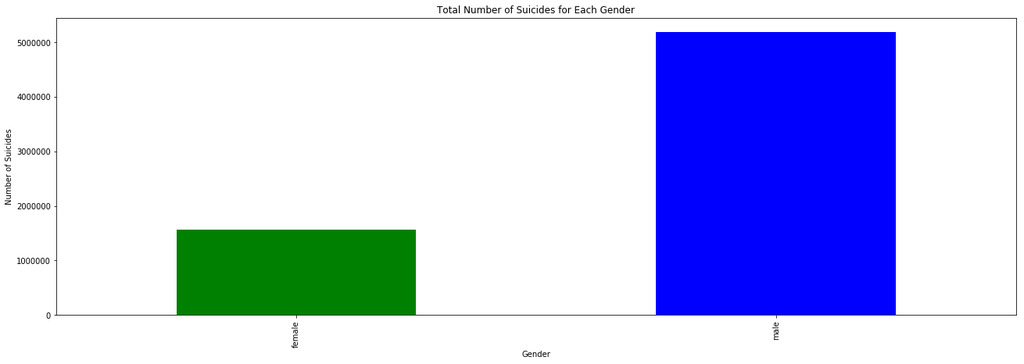

```python
suicide_rates.groupby('sex').suicides_no.sum().plot(kind = 'bar', figsize = (22, 7), color = ['green', 'blue']) #grouping data and plotting bar plot
plt.xlabel("Gender")
plt.ylabel("Number of Suicides")
plt.title("Total Number of Suicides for Each Gender")
plt.show()
```

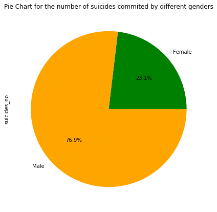

```python
suicide_rates.groupby('sex').suicides_no.sum().plot(kind = 'Pie', figsize = (22, 7), colors = ['green', 'orange'], labels = ['Female', 'Male'], autopct='%1.1f%%')
plt.title("Pie Chart for the number of suicides commited by different genders")
plt.show()
```

The number of suicides reported in our data set is dominated by men, it seems.

I'm going to see if the same five countries have the most number of female and male suicides.

```python
fig = make_subplots(rows = 1, cols = 2) #initializing subplots and specifying rows and columns
gender_suicides('male', 1, 1)
gender_suicides('female', 1, 2)
fig.update_layout(title = "Countries with most number of Male Suicides (Left) and Female Suicides (Right)")
fig.show()
```

[interactive chart not shown]

As expected, men have much higher rates of suicide than women. Almost all of these numbers can be explained by gender roles and disparities alone. For men, the countries listed have generally high numbers of suicides. Gender roles and lack of mental health awareness in men is a significance factor. Moreover, women have higher suicide attempts than men, so there are better chances of them getting timely treatment in the event that their suicide attempt is not succesively. Ironically though, the gender disparity between men and women might also be a reason contributing to higher rates of suicides among men. Men have easier access to firearms - a huge proportion of suicides among men are carried out by firearms and other violent weapons - than women.

The high number of suicides among women in Japan can be attributed to the general reason behind Japan's suicide rate - isolation, high work and finanicial pressure being some of the many factors. Among the demographic of women who have commited suicide in Republic of Korea, most of them are elderly women (aged above 75+). France's inclusion is due to problems its society has been struggling with throughout the decades - social hierarchy, mass unemployment, and an attitude of pessimism that academics have said is not a mere stereotype! [source](http://translate.google.com/translate?hl=en&sl=auto&tl=en&u=http%3A%2F%2Ftheconversation.com%2Fles-fondements-culturels-du-pessimisme-francais-au-travail-entre-histoire-et-ecole-84489)

I'm going to compare suicide rates per 100,000 people over the years as well, to see if it's any different:

```python
fig = make_subplots(rows = 1, cols = 2)
gender_suicides_relative('male', 1, 1)
gender_suicides_relative('female', 1, 2)
fig.update_layout(title = " Countries with High Male(Left) and Female (Right) Mortality Rates")
fig.show()
```

[interactive chart not shown]

Lithuania has higher mortality rate than its birth rate. This is mainly owed to high rates of depression, coupled with mass unemployment and economic decline trieggered by its separation from the Soviet Union. Social neglect of psychiatric illness is still prevalent and so is the active influence of drugs. [source](https://www.cambridge.org/core/services/aop-cambridge-core/content/view/22858FC4A7651DCC4A11B9C02A612AAC/S0955603600054490a.pdf/psychiatry_in_lithuania_the_highest_rate_of_suicide_in_the_world.pdf)

One of the biggest methods of suicides in Sri Lanka have been toxic pesticides, the banning of which has reduced suicides significantly. Poverty is one of the main socioeconomic factors Sri Lanka struggles with the most and before recent times, these pesticides were easily available.

## 3. Analysis by Age Group and Demographic:

First I will look at the distribution of suicides among the different age groups in general from 1985 to 2016:

```python
fig = go.Figure() #initializing plotly figure
df = pd.DataFrame(suicide_rates.groupby(['age']).suicides_no.sum()).reset_index() #grouping data by age and converting to data frame
fig.add_trace(go.Bar( #adding trace for bar plot
    x = df['age'],
    y = df['suicides_no']
))
fig.update_layout(title = "Number of Suicides Recorded for each Age Group")
fig.show()
```

[interactive chart not shown]

It seems that people aged from 35-54 have committed the most number of suicides by far, with the numbers almost touching 2.5 million. The 55-74 age group also passes 1.5 million. Since my dataset consists of countries that fought in the World War II (United States also participated in the Cold War) I would conjecture that this has also been the effect of war. Substance abuse problems, lack of awareness regarding mental health, legal and family problems are among the top reasons for the high number of suicides among middle aged people.

I want to look at the same division of suicide rates over 1985 - 2016 by sex:

```python
df = pd.DataFrame(suicide_rates.groupby(['age', 'sex']).suicides_no.sum()).reset_index().pivot_table(values = 'suicides_no', index = 'age', columns = 'sex')
fig = make_subplots(rows = 1, cols = 2)
fig.add_trace(go.Bar(
    x = df.index,
    y = df['male'],
    name = "Suicides by Males"
), row = 1, col = 1)
fig.add_trace(go.Bar(
    x = df.index,
    y = df['female'],
    name = "Suicides by Females"
), row =1, col = 2)
fig.update_layout(title = "Suicide Numbers over each Age Group for Males (Left) and Females (Right) ")
fig.show()
```

[interactive chart not shown]

Women and men have the same distributions for the age groups 5-14, and 15-24. People aged between 35 and 54 still lead the graphs albeit men in much larger nubmers than women. However, the number women aged 55-74 who commited suicide are very close to the number of women aged 35-54 who commited suicide. This is not seen in the graph for males.

```python
df = pd.DataFrame(suicide_rates.groupby(['age', 'sex']).rate_per_hundredkpop.mean()).reset_index().pivot_table(values = 'rate_per_hundredkpop', index = 'age', columns = 'sex')
fig = make_subplots(rows = 1, cols = 2)
fig.add_trace(go.Bar(
    x = df.index,
    y = df['male'],
    name = "Suicides by Males"
), row = 1, col = 1)
fig.add_trace(go.Bar(
    x = df.index,
    y = df['female'],
    name = "Suicides by Females"
), row =1, col = 2)
fig.update_layout(title = "Mortality Rate over each Age Group for Males (Left) and Females (Right)")
fig.show()
```

[interactive chart not shown]

The lower number of suicides among women compared to men is palpable in these graphs. One of the reasons for thsi is that men have easier access to firearms. Among women some of the reasons have been old age and isolation, death of partner, and physical pain due to natural causes or illness. Suicide among the eldery is a health concern in the United States.

Looking at the number of suicides for each age group over the years:

[figure not shown]

```python
suicide_rates.groupby(['year','age', 'sex']).suicides_no.sum().reset_index().pivot_table(values = 'suicides_no', index = 'year', columns = 'age').plot(figsize = (22,7))
plt.legend(bbox_to_anchor=(1.04,1), loc="upper left")
plt.title("Change in Number of Suicides for each Age Group")
plt.xlabel("Years")
plt.ylabel("Number of Suicides")
plt.show()
```

Top five countries where each age group has had the most casualties and highest mortality rates :

```python
fig = make_subplots(rows = 3, cols = 2)
age_group_maximum('5-14years', 1, 1)
age_group_maximum('15-24years', 1, 2)
age_group_maximum('25-34years',2,1)
age_group_maximum('35-54years',2,2)
age_group_maximum('55-74years',3,1)
age_group_maximum('75+years',3,2)
fig.update_layout(title = "Top Five Countries where each Age Group has the Highest Suicides")
fig.show()
```

[interactive chart not shown]

```python
fig = make_subplots(rows = 3, cols = 3)
age_group_maximum_rate('5-14years', 1, 1)
age_group_maximum_rate('15-24years', 1, 2)
age_group_maximum_rate('25-34years',2,1)
age_group_maximum_rate('35-54years',2,2)
age_group_maximum_rate('55-74years',3,1)
age_group_maximum_rate('75+years',3,2)
fig.update_layout(title = "Top Five Countries where each Age Group has the Highest Mortality Rate")
fig.show()
```

[interactive chart not shown]

Small countries such as Kiribati (which forms a part of the Pacific Islands, regions known for having high suicide rates), Suriname and Guyana in South America have problems with poverty, family dysfunction and metal health decline. Suicide mortality rates for young age groups from 5-15 are thus highest in these countries.

Among the elderly, suicides in Serbia are attributed to high rates of late life neuro-psychiatric disorders, along with the typical financial unrest and social isolation.

## 4. Analysis by GDP:

I want to check whether GDP data has any correlation or causation with suicides and rates. For this, I'm going to look at the top five countries with the highest GDP per year and per capita values and see what their distribuion of suicides and mortality rates are. I'm also going to look at the countries with the lowest GDP values and see if that suggests anything.

First I'll indentify the countries with the highest mean GDP per year values.

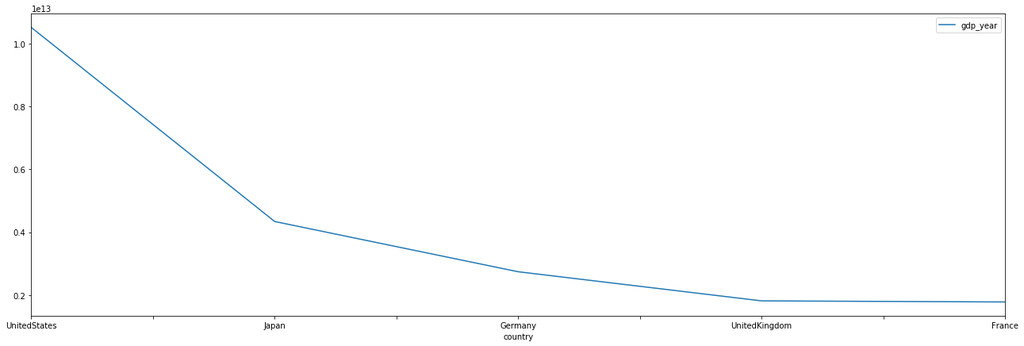

```python
df = pd.DataFrame(suicide_rates.groupby(['country']).gdp_year.mean()).sort_values(by = 'gdp_year', ascending = False).head(5).plot(figsize = (22, 7))
```

Now that I have my list, I'll plot graphs to see how the suicide numbers are affected with the change in GDP per Capita:

```python
fig = make_subplots(rows=3, cols=2,
                    specs=[[{"secondary_y": True}, {"secondary_y": True}],
                          [{"secondary_y": True}, {"secondary_y": True}],
                          [{"secondary_y": True},{"secondary_y": True}]])
suicides_and_gdp_per_capita('UnitedStates', 1, 1, "United States Suicides", "United States GDP per Capita")
suicides_and_gdp_per_capita('Japan', 1, 2, "Japan Suicides", "Japan GDP per Capita")
suicides_and_gdp_per_capita('Germany',2,1, "Germany Suicides", "Germany GDP per Capita")
suicides_and_gdp_per_capita('UnitedKingdom',2,2, "United Kingdom Suicides", "United Kingdom GDP per Capita")
suicides_and_gdp_per_capita('France',3,1, "France Suicides", "France GDP per Capita")
fig.show()
```

[interactive chart not shown]

Beside United States, for the most part, suicide numbers are seen to decrease with general rise in GDP per capitas. The relationship is, however, not linear.

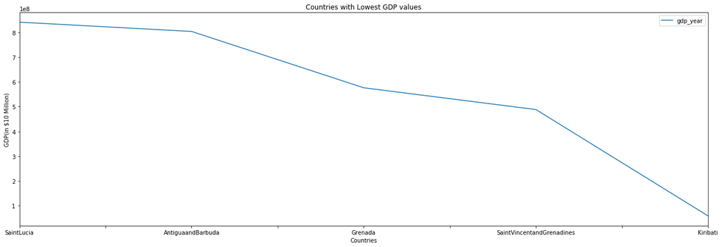

```python
pd.DataFrame(suicide_rates.groupby(['country']).gdp_year.mean()).sort_values(by = 'gdp_year', ascending = False).tail(5).plot(figsize = (22, 7))
plt.title("Countries with Lowest GDP values")
plt.xlabel("Countries")
plt.ylabel("GDP(in $10 Million)")
plt.show()
```

```python
fig = make_subplots(rows=3, cols=2,
                    specs=[[{"secondary_y": True}, {"secondary_y": True}],
                          [{"secondary_y": True}, {"secondary_y": True}],
                          [{"secondary_y": True},{"secondary_y": True}]])
suicides_and_gdp_per_capita('SaintLucia',1,1, "St. Lucia Suicides", "St.Lucia GDP per Capita")
suicides_and_gdp_per_capita('AntiguaandBarbuda',1,2, "ATG Suicides", "ATG GDP per Capita")
suicides_and_gdp_per_capita('Grenada', 2, 1, "Grenada Suicides", "Grenada GDP per Capita")
suicides_and_gdp_per_capita('SaintVincentandGrenadines', 2, 2, "SVG", "SVG GDP per Capita")
suicides_and_gdp_per_capita('Kiribati',3,1, "KI Suicides", "KI GDP per Capita")
fig.update_layout(title = "Comparing the Change in Number of Suicides with the Change in GDP for Countries with Low GDPs")
fig.show()
```

[interactive chart not shown]

Not much can be made from these plots either, suggesting that other factors must be included when looking at relationships and ocrrelations causing suicides.

## 5. A Closer Look at USA:

Since the United States is a country of interest for me and also displays a worry trend in rising suicides, I wanted take a closer look at the suicides in the United States - particularly which race and gender is at the most risk and what the trend has been so far. For this I obtained a data set from containing the suicides across all states and the races and genders of the people who commited suicide from the [cdc website](https://wonder.cdc.gov/).

Reading the data in and looking at the first few entries:

```python
usa_rates = pd.DataFrame(pd.read_csv("usa_suicides.csv")) #reading in the csv file and converting to data frame
usa_rates.columns #looking at the first five rows
usa_rates = usa_rates.rename(columns = {'Ten-Year Age Groups Code': 'Age'})
usa_rates.head(5)
```

|  | Notes | State | State Code | Ten-Year Age Groups | Age | Race | Race Code | Gender | Gender Code | Deaths | Population | CrudeRate | % of Total Deaths |
| --- | --- | --- | --- | --- | --- | --- | --- | --- | --- | --- | --- | --- | --- |
| 0 | NaN | Alabama | 1.0 | 5-14 years | 5-14 | Black or African American | 2054-5 | Male | M | 27.0 | 1923557.0 | 1.4 | 0.0% |
| 1 | NaN | Alabama | 1.0 | 5-14 years | 5-14 | White | 2106-3 | Female | F | 24.0 | 3806104.0 | 0.6 | 0.0% |
| 2 | NaN | Alabama | 1.0 | 5-14 years | 5-14 | White | 2106-3 | Male | M | 43.0 | 4016345.0 | 1.1 | 0.0% |
| 3 | NaN | Alabama | 1.0 | 15-24 years | 15-24 | Asian or Pacific Islander | A-PI | Male | M | 10.0 | 92376.0 | 0.0 | 0.0% |
| 4 | NaN | Alabama | 1.0 | 15-24 years | 15-24 | Black or African American | 2054-5 | Female | F | 24.0 | 2065832.0 | 1.2 | 0.0% |

I will be using the columns 'State', 'Age', 'Race', 'Deaths', 'Gender', and later, 'CrudeRate' for my analysis.

First of, I'll look at the distribution of suicides by gender:

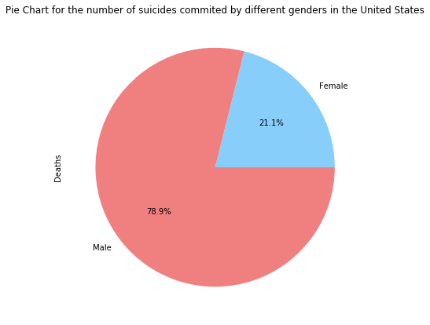

```python
usa_rates.groupby('Gender').Deaths.sum().plot(kind = 'Pie', figsize = (22, 7), colors = ['lightskyblue', 'lightcoral'], labels = ['Female', 'Male'], autopct='%1.1f%%') #grouping data by gender and plotting a Pie chart
plt.title("Pie Chart for the number of suicides commited by different genders in the United States") #adding a title
plt.show()
```

As expected by now, males dominate the chart for suicides.

States where number of suicides is highest:

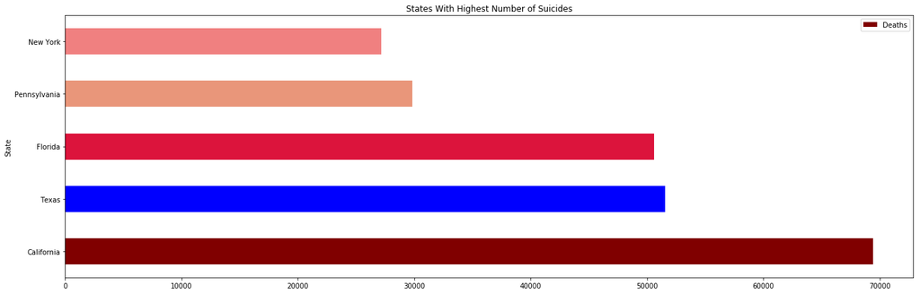

```python
df = pd.DataFrame(usa_rates.groupby('State').Deaths.sum()).reset_index().sort_values(by = 'Deaths', ascending = False)
df.head(5).plot(x = 'State', y = 'Deaths', figsize = (22, 7), kind = 'barh', color =['maroon', 'blue', 'crimson', 'darksalmon', 'lightcoral'])
plt.title("States With Highest Number of Suicides")
plt.show()
```

California has the highest number of suicides, followed by Texas, Florida, Pennsylvania, and New York. California ia huge state and there is a lot of regional disparity present. In the rural areas, mental health facilities are not avaliable and suicides in these parts are high. The same can be said for Texas.

Alongside the typical factors, such as poverty and mental health, the failure of the health agencies to capitalize on suicide prevention methods is also a contributor. Florida and Pennsylvania too, suffer from a public health issue, while New York also exhibits huge regional disparities. The city areas of New York have much lower suicide rates than the more rural areas, as they are heavily populated with mental health clinics and agencies. This is not the case for rural areas.

Comparing states which have the maximum number of suicides for males and females:

```python
df = pd.DataFrame(usa_rates.groupby(['State', 'Gender']).Deaths.sum()).reset_index()
df_male = df[df['Gender'] == 'Male'].sort_values(by = 'Deaths', ascending = False).head(5)
df_female = df[df['Gender'] == 'Female'].sort_values(by = 'Deaths', ascending = False).head(5)
fig = go.Figure(data=[
    go.Bar(name='Males', x=df_male['State'], y=df_male['Deaths']),
    go.Bar(name='Females', x=df_female['State'] , y=df_female['Deaths'])
])
# Change the bar mode
fig.update_layout(barmode='group', title = "States in the U.S with Highest Number of Suicides for Men and Women")
fig.show()
```

[interactive chart not shown]

### Introducing a new measure for analysis - Crude Rate:

There are four major ethnic groups in USA - White, African American, Asian or Pacific Islanders, and American Indians or Alaska Natives. I'm going to look at two plots - one displaying the breakdown of Suicide Crude Rates for every age group (colored by Race) and another for the breakdown of Suicide Crude Rates for every race (colored by Gender):

```python
df = pd.DataFrame(usa_rates.groupby(['Age', 'Race', 'CrudeRate']).Deaths.sum()).reset_index()
df_white = pd.DataFrame(df[df['Race'] == 'White'].groupby(['Age', 'Race']).CrudeRate.mean()).reset_index()
df_afa = pd.DataFrame(df[df['Race'] == 'Black or African American'].groupby(['Age', 'Race']).CrudeRate.mean()).reset_index()
df_ap = pd.DataFrame(df[df['Race'] == 'Asian or Pacific Islander'].groupby(['Age', 'Race']).CrudeRate.mean()).reset_index()
df_ai = pd.DataFrame(df[df['Race'] == 'American Indian or Alaska Native'].groupby(['Age', 'Race']).CrudeRate.mean()).reset_index()
fig = go.Figure(data=[
    go.Bar(name='White', x=df_white['Age'], y=df_white['CrudeRate']),
    go.Bar(name='Black or African American', x=df_afa['Age'] , y=df_afa['CrudeRate']),
    go.Bar(name='Asian or Pacific Islander', x=df_ap['Age'] , y=df_ap['CrudeRate']),
    go.Bar(name='American Indian or Alaska Native', x=df_ai['Age'] , y=df_ai['CrudeRate'])])
#Change the bar mode
fig.update_layout(barmode='group', title = "Breakdown of Suicide Crude Rates in USA by Race", xaxis_title = "Age Groups Colored by Race", yaxis_title = "Crude Rate for Suicides")
fig.show()
```

[interactive chart not shown]

```python
df = pd.DataFrame(usa_rates.groupby(['Gender', 'Race', 'CrudeRate']).Deaths.sum()).reset_index()
df_male = df[df['Gender'] == 'Male']
df_male_race = pd.DataFrame(df_male.groupby(['Gender', 'Race']).CrudeRate.mean()).reset_index()
df_female = df[df['Gender'] == 'Female']
df_female_race = pd.DataFrame(df_female.groupby(['Gender', 'Race']).CrudeRate.mean()).reset_index()
fig = go.Figure(data=[
    go.Bar(name='Male', x=df_male_race['Race'], y=df_male_race['CrudeRate']),
    go.Bar(name='Female', x=df_female_race['Race'] , y=df_female_race['CrudeRate'])])
#Change the bar mode
fig.update_layout(barmode='group', title = "Breakdown by Gender of Race Groups at most Risk of Suicide", xaxis_title = "Ethnic Groups Colored by Gender", yaxis_title = "Crude Suicide Rate")
fig.show()
```

[interactive chart not shown]

The two graphs show alarming results. The ethnic group that is most at risk are American Indian or Alaska Native youth. Their numbers exceed that of White suicide rates (the second highest and most prevalent over the years) in most age groups. The factors behind high American Indian youth Suicide rates (while matching the global general conceptions of factors behind suicides) also have their own additional contributors. While alcohol usage is a kew factor in this group as well, it is particularly pervasive for American Indians with alcohol consumption 97% reporting to consuming alcohol before they were 18 and more than ten percent of the population admitting to being regular drinkers before turning 9.

Poor health, individual and community depression, and lack of education also showed high correlations with suicides, research has shown. Family violence and neglect, which for Indian youth has shown a high correlation with suicides, is more prevalent in the case of American Indian communites.

In the second graph, we see that American Indian males are at the most risk. This can also be explained, along with the previously mentioned factors, by the influence of family deviance on American Indian males. American Indian males have been seen to more likely be influenced by factors such as marriage outside networks, paternal violence, alcoholism and negliegence.

African American have the lowest suicide rates - studies have shown, however, that they have the highest suicide attempt rates.

### Unemployment Rates:

Before ending my project I wanted to see if unemployment rates could shed light on suicide rates. I imported a dataset containing unemployment rates forevery month from the years 1989-2017 [from Kaggle](https://www.kaggle.com/junfeng142857/usa-unemployment-rate-from-1989-to-2017#unemployment_rate.csv) into pandas and made a new column containing the overall unemployment rate for each year:

```python
unemployment = pd.DataFrame(pd.read_csv("unemployment_rate.csv"))
unemployment = unemployment.set_index('Year')
unemployment['rate_for_year'] = unemployment.loc[:,'Jan':'Dec'].sum(axis = 1) / 12
unemployment.head(3)
```

| Year | Jan | Feb | Mar | Apr | May | Jun | Jul | Aug | Sep | Oct | Nov | Dec | rate_for_year |
| --- | --- | --- | --- | --- | --- | --- | --- | --- | --- | --- | --- | --- | --- |
| 1989 | 5.4 | 5.2 | 5.0 | 5.2 | 5.2 | 5.3 | 5.2 | 5.2 | 5.3 | 5.3 | 5.4 | 5.4 | 5.258333 |
| 1990 | 5.4 | 5.3 | 5.2 | 5.4 | 5.4 | 5.2 | 5.5 | 5.7 | 5.9 | 5.9 | 6.2 | 6.3 | 5.616667 |
| 1991 | 6.4 | 6.6 | 6.8 | 6.7 | 6.9 | 6.9 | 6.8 | 6.9 | 6.9 | 7.0 | 7.0 | 7.3 | 6.850000 |

Looking at the last few rows and removing observations after 2015:

```python
unemployment = unemployment.drop([2016, 2017], axis = 0)
unemployment.tail(3)
unemployment = unemployment.reset_index()
```

I then plotted the change in unemployment rates with the change in suicides over the years:

```python
df_usa = pd.DataFrame(suicide_rates[suicide_rates['country'] == 'UnitedStates'].groupby(['year']).suicides_no.sum()).reset_index()
fig = make_subplots(specs=[[{"secondary_y": True}]])
#adding the trace for a Scatter Plot
fig.add_trace(go.Scatter(
    x = df_usa['year'], #setting values in X axis
    y = df_usa['suicides_no'], #values in Y axis
    name = "Suicides" #naming the trace
), secondary_y = False)
#adding trace for suicides
fig.add_trace(go.Scatter(
    x = unemployment['Year'], #adding the year values in the X axis
    y = unemployment['rate_for_year'], #plotting the Y axis
    name = "Unemployment Rate"
), secondary_y= True) #adding the secondary axis
fig.show()
```

[interactive chart not shown]

Though one would assume that USA hitting its lowest unemployment rates in three decades would imply a decline in the number of suicides, this is not reflected in the plot above. This could also be due to the fact that analysis shows that lower unemployment rate is not a reliable assurance that everyone in the population has jobs (as counter intuitive as it sounds) - unemployment rates do not account for discouraged workers (in the case of USA, workers who haven't looked for jobs in more than four weeks). Discouraged workers are considered to be part of the labor force and thus, not counted in any employment studies.

# Conclusions (Possible Predicitions and Ways to Improve this Study):

- The only thing keeping Russia at the top for high number of suicides is the sheer magnitude it displayed on the late 90s and early 2000s - other than that it's showing a gradual decline. USA is already at heads with Japan, and will soon overtake Russia as the country with the highest suicide numbers.
- If not accounted for quick with proper research and applications, suicides in the United States will continue to rise at steep rates. The mortality rate declining over the years will not signify anything positive.
- American Indians and Alaska Natives are in dire need of social intervention. I noticed an observation for a year where American Indian crude rate suicides showed a value of 152 - a value of 20 is considered to by high!
- Owing to societal gender roles, easier access to firearms and lack of awareness, men are more likely to commit suicide than women though women have more attempts. This is also detrimental, as people generally tend to dismiss suicide attempts as 'attention seeking behavior' instead of identifying it for what it is - a potential risk.
- I would suggest more research into suicides for specific ethnic and regional groups.Suicides rates and factors are very region specific. Specialized and ground level research is integral as a means of understanding the necessary correlations after which attempts at regression models to predict and prevent suicides can even be considered.

# References:

[Population Change and Distribution(Census 2000 Brief)](https://www.census.gov/prod/2001pubs/c2kbr01-2.pdf)

[Heavy Drinking and Suicide in Russia](https://www.census.gov/prod/2001pubs/c2kbr01-2.pdf)

[Why Has the Continuous Decline in German Suicide Rates Stopped in 2007?](https://www.ncbi.nlm.nih.gov/pmc/articles/PMC3743810/)

[Robert Enke: International goalkeeper who committed suicide](https://www.independent.co.uk/news/obituaries/robert-enke-international-goalkeeper-who-committed-suicide-1821284.html)

[Rising morbidity and mortality in midlife among white non-Hispanic Americans in the 21st century](https://www.pnas.org/content/112/49/15078)

[Suicide in Hungary-epidemiological and clinical perspectives](https://www.researchgate.net/publication/242332814_Suicide_in_Hungary-epidemiological_and_clinical_perspectives)

[Suicides in Russia and Belarus: A Comparative Analysis of Trends](http://psychopathology.imedpub.com/suicides-in-russia-and-belarus-a-comparative-analysis-of-trends.php?aid=7536)

[The cultural foundations of French pessimism at work, between history and school](http://translate.google.com/translate?hl=en&sl=auto&tl=en&u=http%3A%2F%2Ftheconversation.com%2Fles-fondements-culturels-du-pessimisme-francais-au-travail-entre-histoire-et-ecole-84489) - note: This page is in French and needs to be translated (I've provided the Google Translate link to this page.)

[Psychiatry in Lithuania: the highest rate of suicide in the world](https://www.cambridge.org/core/services/aop-cambridge-core/content/view/22858FC4A7651DCC4A11B9C02A612AAC/S0955603600054490a.pdf/psychiatry_in_lithuania_the_highest_rate_of_suicide_in_the_world.pdf)

[The Reality of Suicide in Sri Lanka: Need for Data-driven analysis](https://groundviews.org/2017/10/06/hype-and-reality-of-suicides-in-sri-lanka-need-for-data-driven-analysis/)

[Suicides and Pesticides in Sri Lanka](https://ajph.aphapublications.org/doi/pdf/10.2105/AJPH.78.7.826)

[Pacific Island Suicide in Comparative Perspective](https://www.researchgate.net/publication/12719174_Pacific_Island_Suicide_in_Comparative_Perspective)

[Suicide in older adults: current perspectives](https://www.ncbi.nlm.nih.gov/pmc/articles/PMC5916258/)

[Suicide Attempts in Serbian Elderly Population – 10 Year Prospective Study](https://www.ecnp.eu/presentationpdfs/71/P.1.k.012.pdf)

[Elderly suicide rates: a replication of cross-national comparisons and association with sex and elderly age-bands using five year suicide data](https://www.ncbi.nlm.nih.gov/pmc/articles/PMC3134928/)

[Here’s what the suicide epidemic looks like in California](https://www.sacbee.com/news/databases/article213068214.html)

Suicide Among American Indian, Alaskan Native, and Canadian Aboriginal Youth: Advancing the Research Agenda